# Meta-analysis physiological costs of hibernation: Report 5 - Arousal Immune parameters

Pablo Capilla-Lasheras

2025-04-07

This [R Markdown](http://rmarkdown.rstudio.com) Notebook contains the initial meta-analysis for the project ‘physiological ’costs’ of hibernation.

## Dataset and calculation of effect sizes

The dataset for this meta-analysis has been collected after a literature search by Pablo Burraco, Marko Prokic and Tamara Petrovic. It contains data on physiological effects of hibernation in different systems. Here a quick snapshot of the first lines of the dataset:

|  | Study | Year | Study_ID | Species | Family | Genus | Common.name | Type_of_animal | Thermoregulation | Class | Ver_Invert | Developmental_stage | Location | Experiment_venue | Biological.process | Tissue | Experimental_manipulation | Experimental.value | Biomarker_category | Specific_marker | Unit | Euthermia_N | Euthermia_M | Euthermia_SD | Euthermia_SE | Hib_N | Hib_M | Hib_SD | Hib_SE | … |
| --- | --- | --- | --- | --- | --- | --- | --- | --- | --- | --- | --- | --- | --- | --- | --- | --- | --- | --- | --- | --- | --- | --- | --- | --- | --- | --- | --- | --- | --- | --- |
| 1 | Cooper et al 2016 | 2016 | study516 | Ictidomys tridecemlineatus | Sciuridae | Ictidomys | thirteen-lined ground squirrel | Rodent | Endothermic | Mammalia | Vertebrate | adult | United States | Captive | Hibernation | blood | none | none | Innate | Basophils | 10^3 uL | 9 | 2.000000e-02 | 0.0700000 | NA | 10 | 0.000000e+00 | 0.0000000 | NA | … |
| 2 | Bohr et al 2014 | 2014 | study543 | Ictidomys tridecemlineatus | Sciuridae | Ictidomys | thirteen-lined ground squirrel | Rodent | Endothermic | Mammalia | Vertebrate | adult | United States | laboratory | Hibernation | lung | none | none | Innate | E-selectin | Normalized Densitometric Units | 6 | 5.118959e-02 | NA | 2.743494e-02 | 6 | 6.390335e-02 | NA | 2.040892e-02 | … |
| 3 | Kurtz and Carey 2007 | 2007 | study632 | Ictidomys tridecemlineatus | Sciuridae | Ictidomys | thirteen-lined ground squirrel | Rodent | Endothermic | Mammalia | Vertebrate | adult | United States | laboratory | Hibernation | gut | none | none | Adaptive | IgA | densitometric units | 14 | 5.844749e-02 | NA | 2.739726e-02 | 6 | 9.479452e-01 | NA | 7.305936e-02 | … |
| 4 | Kurtz and Carey 2007 | 2007 | study632 | Ictidomys tridecemlineatus | Sciuridae | Ictidomys | thirteen-lined ground squirrel | Rodent | Endothermic | Mammalia | Vertebrate | adult | United States | laboratory | Hibernation | gut | none | none | Adaptive | IgA | densitometric units | 14 | 5.844749e-02 | NA | 2.739726e-02 | 6 | NA | NA | NA | … |
| 5 | Talaei et al 2012 | 2012 | study678 | Mesocricetus auratus | Cricetidae | Phodopus | Syrian hamster | Rodent | Endothermic | Mammalia | Vertebrate | NA | Netherlands | laboratory | Hibernation | lung | none | none | Both | NF-kB | expression | 4 | 6.473684e-02 | NA | 2.052632e-02 | 4 | 1.389474e-01 | 0.1721053 | 3.315789e-02 | … |
| 6 | Talaei et al 2012 | 2012 | study678 | Mesocricetus auratus | Cricetidae | Phodopus | Syrian hamster | Rodent | Endothermic | Mammalia | Vertebrate | NA | Netherlands | laboratory | Hibernation | lung | none | none | Both | NF-kB | expression | 4 | 6.473684e-02 | NA | 2.052632e-02 | 4 | 9.631579e-02 | 0.1136842 | 1.736842e-02 | … |
| 7 | Talaei et al 2012 | 2012 | study678 | Mesocricetus auratus | Cricetidae | Phodopus | Syrian hamster | Rodent | Endothermic | Mammalia | Vertebrate | NA | Netherlands | laboratory | Hibernation | lung | none | none | Both | VCAM-1 | expression | 4 | 9.767442e-02 | NA | 1.395349e-02 | 4 | 1.430233e-01 | 0.1866279 | 4.360465e-02 | … |
| 8 | Talaei et al 2012 | 2012 | study678 | Mesocricetus auratus | Cricetidae | Phodopus | Syrian hamster | Rodent | Endothermic | Mammalia | Vertebrate | NA | Netherlands | laboratory | Hibernation | lung | none | none | Both | VCAM-1 | expression | 4 | 9.767442e-02 | NA | 1.395349e-02 | 4 | 1.447674e-01 | 0.1988372 | 5.406977e-02 | … |
| 9 | Cooper et al 2016 | 2016 | study516 | Ictidomys tridecemlineatus | Sciuridae | Ictidomys | thirteen-lined ground squirrel | Rodent | Endothermic | Mammalia | Vertebrate | adult | United States | Captive | Hibernation | blood | none | none | Innate | Eosinophils | 10^3 uL | 9 | 1.200000e-01 | 0.1900000 | NA | 10 | 1.000000e-02 | 0.0100000 | NA | … |
| 10 | Schwanz et al. 2011 | 2011 | study647 | Chrysemys picta | Emydidae | Chrysemys | painted turtle | Turtle | Ectothermic | Reptilia | Vertebrate | adult_male | United States | field/captive | Hibernation | blood | none | none | Innate | Monocytes | 10^3 uL | 19 | 1.343284e-01 | NA | 4.776119e-02 | 19 | 1.313433e-01 | NA | 4.179104e-02 | … |

[output cut: 231 more lines]

As a summary of the *initial dataset*:

- Number of studies: 20
- Number of species: 12

For this meta-analysis, I am going to include all immune (IM) markers and calculate the standarised mean difference (g) as the effect size of analysis comparing **arousal** *versus* **euthermia**. Positive SMD values indicate higher IM values in *arousal* while negative SMD indicate lower IM values in *arousal*. This is a summary of the effect size calculation based on the dataset above:

Summary of SMD_arousal effect size and number of observations included in the meta-analysis:

```
##    Min. 1st Qu.  Median    Mean 3rd Qu.    Max.
## -3.3649 -0.3001  0.2421  0.3971  1.0977  4.8729
```

- Number of observation with non-missing SMD_arousal: 194
- Number of studies in the dataset for analysis: 12
- Number of species in the dataset for analysis: 6

## Initial meta-analysis:

This initial model contains only the intercept and five random effects to account for variation between between classes, families, species, between studies and within studies beyond sampling variance.

```r
model_SMD_arousal <- rma.mv(yi = SMDH_arousal,
                     V = SMDH.sv_arousal,
                     mods = ~ 1,
                     random = list(~1|Study_ID,
                                   ~1|Class,
                                   ~1|Family,
                                   ~1|Species,
                                   ~1|obsID),
                     data=df_SMD_arousal,
                     method="REML")
```

```
##
## Multivariate Meta-Analysis Model (k = 194; method: REML)
##
##    logLik   Deviance        AIC        BIC       AICc
## -286.9019   573.8038   585.8038   605.3799   586.2554
##
## Variance Components:
##
##             estim    sqrt  nlvls  fixed    factor
## sigma^2.1  0.0000  0.0000     12     no  Study_ID
## sigma^2.2  0.0000  0.0001      2     no     Class
## sigma^2.3  0.0000  0.0003      4     no    Family
## sigma^2.4  0.5141  0.7170      6     no   Species
## sigma^2.5  0.3318  0.5760    194     no     obsID
##
## Test for Heterogeneity:
## Q(df = 193) = 412.1360, p-val < .0001
##
## Model Results:
##
## estimate      se    zval    pval    ci.lb   ci.ub
##   0.3827  0.3144  1.2175  0.2234  -0.2334  0.9989
##
## ---
## Signif. codes:  0 '***' 0.001 '**' 0.01 '*' 0.05 '.' 0.1 ' ' 1
```

Proportion of variation left after accounting for sampling variance and proportion accounted by each random effect:

| Variable | i2_value_percentage |
| --- | --- |
| I2_Total | 69.227 |
| I2_Study_ID | 0.000 |
| I2_Class | 0.000 |
| I2_Family | 0.000 |
| I2_Species | 42.070 |
| I2_obsID | 27.157 |

### Plot of results of intercept-only model:

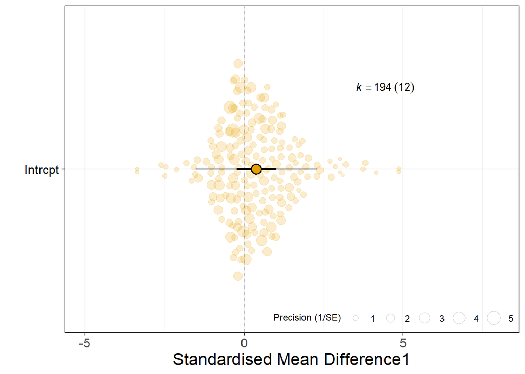

### Publication bias: small-study effects

```
##
## Multivariate Meta-Analysis Model (k = 194; method: REML)
##
##    logLik   Deviance        AIC        BIC       AICc
## -285.7627   571.5254   585.5254   608.3279   586.1341
##
## Variance Components:
##
##             estim    sqrt  nlvls  fixed    factor
## sigma^2.1  0.0109  0.1042     12     no  Study_ID
## sigma^2.2  0.0000  0.0000      2     no     Class
## sigma^2.3  0.0000  0.0003      4     no    Family
## sigma^2.4  0.4776  0.6911      6     no   Species
## sigma^2.5  0.3311  0.5754    194     no     obsID
##
## Test for Residual Heterogeneity:
## QE(df = 192) = 397.4045, p-val < .0001
##
## Test of Moderators (coefficient 2):
## QM(df = 1) = 0.3518, p-val = 0.5531
##
## Model Results:
##
##                   estimate      se    zval    pval    ci.lb   ci.ub
## intrcpt             0.1883  0.4463  0.4219  0.6731  -0.6864  1.0630
## sqrt(inv_eff_ss)    0.3733  0.6293  0.5931  0.5531  -0.8602  1.6068
##
## ---
## Signif. codes:  0 '***' 0.001 '**' 0.01 '*' 0.05 '.' 0.1 ' ' 1
```

```
##    R2_marginal R2_conditional
##    0.003189195    0.597289921
```

### Publication bias: time-lag effects

```
##
## Multivariate Meta-Analysis Model (k = 194; method: REML)
##
##    logLik   Deviance        AIC        BIC       AICc
## -285.2473   570.4945   584.4945   607.2970   585.1032
##
## Variance Components:
##
##             estim    sqrt  nlvls  fixed    factor
## sigma^2.1  0.2432  0.4932     12     no  Study_ID
## sigma^2.2  0.0000  0.0000      2     no     Class
## sigma^2.3  0.0000  0.0000      4     no    Family
## sigma^2.4  0.0001  0.0081      6     no   Species
## sigma^2.5  0.3070  0.5541    194     no     obsID
##
## Test for Residual Heterogeneity:
## QE(df = 192) = 407.8518, p-val < .0001
##
## Test of Moderators (coefficient 2):
## QM(df = 1) = 2.8776, p-val = 0.0898
##
## Model Results:
##
##              estimate      se    zval    pval    ci.lb   ci.ub
## intrcpt        0.3828  0.1694  2.2593  0.0239   0.0507  0.7148  *
## scale(Year)    0.3063  0.1805  1.6964  0.0898  -0.0476  0.6601  .
##
## ---
## Signif. codes:  0 '***' 0.001 '**' 0.01 '*' 0.05 '.' 0.1 ' ' 1
```

```
##    R2_marginal R2_conditional
##      0.1456274      0.5233566
```

Number of observations for each type:

```
##
## Adaptive     Both   Innate
##       41       42      111
```

```
##
## Multivariate Meta-Analysis Model (k = 194; method: REML)
##
##    logLik   Deviance        AIC        BIC       AICc
## -282.1122   564.2243   580.2243   606.2425   581.0156
##
## Variance Components:
##
##             estim    sqrt  nlvls  fixed    factor
## sigma^2.1  0.3402  0.5832     12     no  Study_ID
## sigma^2.2  0.0000  0.0000      2     no     Class
## sigma^2.3  0.0000  0.0000      4     no    Family
## sigma^2.4  0.0000  0.0002      6     no   Species
## sigma^2.5  0.2902  0.5387    194     no     obsID
##
## Test for Residual Heterogeneity:
## QE(df = 191) = 406.2751, p-val < .0001
##
## Test of Moderators (coefficients 1:3):
## QM(df = 3) = 11.6366, p-val = 0.0087
##
## Model Results:
##
##                             estimate      se     zval    pval    ci.lb   ci.ub
## Biomarker_categoryAdaptive   -0.1272  0.2512  -0.5064  0.6126  -0.6196  0.3652
## Biomarker_categoryBoth        0.3277  0.2315   1.4154  0.1570  -0.1261  0.7816
## Biomarker_categoryInnate      0.5765  0.2148   2.6843  0.0073   0.1555  0.9974
##
## Biomarker_categoryAdaptive
## Biomarker_categoryBoth
## Biomarker_categoryInnate    **
##
## ---
## Signif. codes:  0 '***' 0.001 '**' 0.01 '*' 0.05 '.' 0.1 ' ' 1
```

```
##
## Multivariate Meta-Analysis Model (k = 194; method: REML)
##
##    logLik   Deviance        AIC        BIC       AICc
## -282.1122   564.2243   580.2243   606.2425   581.0156
##
## Variance Components:
##
##             estim    sqrt  nlvls  fixed    factor
## sigma^2.1  0.3402  0.5832     12     no  Study_ID
## sigma^2.2  0.0000  0.0000      2     no     Class
## sigma^2.3  0.0000  0.0000      4     no    Family
## sigma^2.4  0.0000  0.0002      6     no   Species
## sigma^2.5  0.2902  0.5387    194     no     obsID
##
## Test for Residual Heterogeneity:
## QE(df = 191) = 406.2751, p-val < .0001
##
## Test of Moderators (coefficients 1:3):
## QM(df = 3) = 11.6366, p-val = 0.0087
##
## Model Results:
##
##                             estimate      se     zval    pval    ci.lb   ci.ub
## Biomarker_categoryAdaptive   -0.1272  0.2512  -0.5064  0.6126  -0.6196  0.3652
## Biomarker_categoryBoth        0.3277  0.2315   1.4154  0.1570  -0.1261  0.7816
## Biomarker_categoryInnate      0.5765  0.2148   2.6843  0.0073   0.1555  0.9974
##
## Biomarker_categoryAdaptive
## Biomarker_categoryBoth
## Biomarker_categoryInnate    **
##
## ---
## Signif. codes:  0 '***' 0.001 '**' 0.01 '*' 0.05 '.' 0.1 ' ' 1
```

### Plot of results of biomarker meta-regression:

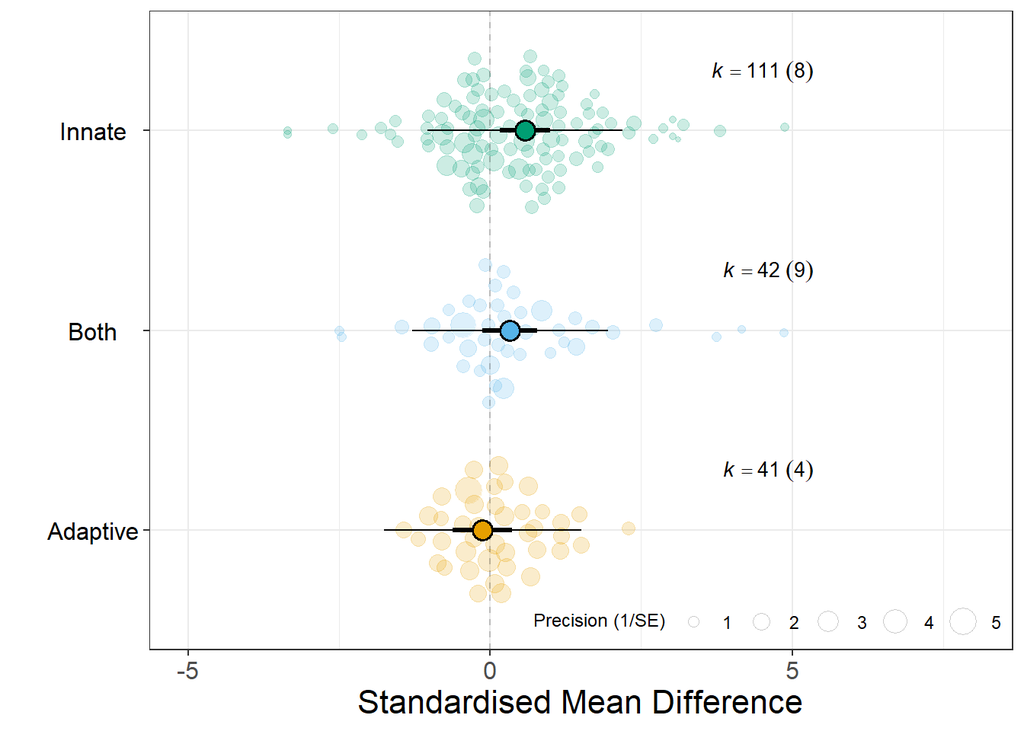

## Meta-analysis including thermoregulation type as a moderator:

Number of observations for each type:

```
##
## Ectothermic Endothermic
##          10         184
```

```
##
## Multivariate Meta-Analysis Model (k = 194; method: REML)
##
##    logLik   Deviance        AIC        BIC       AICc
## -284.8496   569.6992   581.6992   601.2442   582.1532
##
## Variance Components:
##
##             estim    sqrt  nlvls  fixed    factor
## sigma^2.1  0.0000  0.0000     12     no  Study_ID
## sigma^2.2  0.2132  0.4617      2     no     Class
## sigma^2.3  0.6328  0.7955      6     no   Species
## sigma^2.4  0.3340  0.5780    194     no     obsID
##
## Test for Residual Heterogeneity:
## QE(df = 192) = 409.5164, p-val < .0001
##
## Test of Moderators (coefficients 1:2):
## QM(df = 2) = 0.6175, p-val = 0.7344
##
## Model Results:
##
##                              estimate      se     zval    pval    ci.lb   ci.ub
## ThermoregulationEctothermic   -0.0132  0.9443  -0.0140  0.9888  -1.8639  1.8375
## ThermoregulationEndothermic    0.4695  0.5976   0.7857  0.4321  -0.7018  1.6409
##
## ThermoregulationEctothermic
## ThermoregulationEndothermic
##
## ---
## Signif. codes:  0 '***' 0.001 '**' 0.01 '*' 0.05 '.' 0.1 ' ' 1
```

```
##
## Multivariate Meta-Analysis Model (k = 194; method: REML)
##
##    logLik   Deviance        AIC        BIC       AICc
## -284.8496   569.6992   581.6992   601.2442   582.1532
##
## Variance Components:
##
##             estim    sqrt  nlvls  fixed    factor
## sigma^2.1  0.0000  0.0000     12     no  Study_ID
## sigma^2.2  0.2132  0.4617      2     no     Class
## sigma^2.3  0.6328  0.7955      6     no   Species
## sigma^2.4  0.3340  0.5780    194     no     obsID
##
## Test for Residual Heterogeneity:
## QE(df = 192) = 409.5164, p-val < .0001
##
## Test of Moderators (coefficients 1:2):
## QM(df = 2) = 0.6175, p-val = 0.7344
##
## Model Results:
##
##                              estimate      se     zval    pval    ci.lb   ci.ub
## ThermoregulationEctothermic   -0.0132  0.9443  -0.0140  0.9888  -1.8639  1.8375
## ThermoregulationEndothermic    0.4695  0.5976   0.7857  0.4321  -0.7018  1.6409
##
## ThermoregulationEctothermic
## ThermoregulationEndothermic
##
## ---
## Signif. codes:  0 '***' 0.001 '**' 0.01 '*' 0.05 '.' 0.1 ' ' 1
```

### Plot of results of thermoregulation meta-regression:

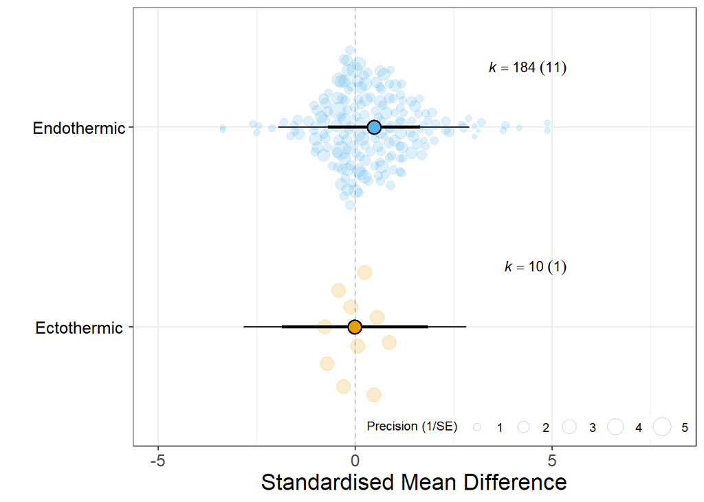

## Endotherms vs. ectotherms:

Now, we investigate if the response to hibernation varies across types of IM for endotherms and ectotherms. We include three types of immune function:

```
##
## Adaptive     Both   Innate
##       41       42      111
```

### Meta-model for endotherms:

- Number of observation with non-missing SMD_arousal: 184
- Number of studies in the dataset for analysis: 11
- Number of species in the dataset for analysis: 5

```
##
## Multivariate Meta-Analysis Model (k = 184; method: REML)
##
##    logLik   Deviance        AIC        BIC       AICc
## -271.1983   542.3965   554.3965   573.5875   554.8793
##
## Variance Components:
##
##             estim    sqrt  nlvls  fixed    factor
## sigma^2.1  0.3655  0.6046     11     no  Study_ID
## sigma^2.2  0.0000  0.0002      5     no   Species
## sigma^2.3  0.2946  0.5428    184     no     obsID
##
## Test for Residual Heterogeneity:
## QE(df = 181) = 371.7643, p-val < .0001
##
## Test of Moderators (coefficients 1:3):
## QM(df = 3) = 14.6937, p-val = 0.0021
##
## Model Results:
##
##                             estimate      se     zval    pval    ci.lb   ci.ub
## Biomarker_categoryAdaptive   -0.1006  0.2609  -0.3855  0.6999  -0.6119  0.4107
## Biomarker_categoryBoth        0.2747  0.2494   1.1016  0.2706  -0.2141  0.7636
## Biomarker_categoryInnate      0.7307  0.2362   3.0942  0.0020   0.2678  1.1935
##
## Biomarker_categoryAdaptive
## Biomarker_categoryBoth
## Biomarker_categoryInnate    **
##
## ---
## Signif. codes:  0 '***' 0.001 '**' 0.01 '*' 0.05 '.' 0.1 ' ' 1
```

```
##
## Multivariate Meta-Analysis Model (k = 184; method: REML)
##
##    logLik   Deviance        AIC        BIC       AICc
## -271.1983   542.3965   554.3965   573.5875   554.8793
##
## Variance Components:
##
##             estim    sqrt  nlvls  fixed    factor
## sigma^2.1  0.3655  0.6046     11     no  Study_ID
## sigma^2.2  0.0000  0.0002      5     no   Species
## sigma^2.3  0.2946  0.5428    184     no     obsID
##
## Test for Residual Heterogeneity:
## QE(df = 181) = 371.7643, p-val < .0001
##
## Test of Moderators (coefficients 1:3):
## QM(df = 3) = 14.6937, p-val = 0.0021
##
## Model Results:
##
##                             estimate      se     zval    pval    ci.lb   ci.ub
## Biomarker_categoryAdaptive   -0.1006  0.2609  -0.3855  0.6999  -0.6119  0.4107
## Biomarker_categoryBoth        0.2747  0.2494   1.1016  0.2706  -0.2141  0.7636
## Biomarker_categoryInnate      0.7307  0.2362   3.0942  0.0020   0.2678  1.1935
##
## Biomarker_categoryAdaptive
## Biomarker_categoryBoth
## Biomarker_categoryInnate    **
##
## ---
## Signif. codes:  0 '***' 0.001 '**' 0.01 '*' 0.05 '.' 0.1 ' ' 1
```

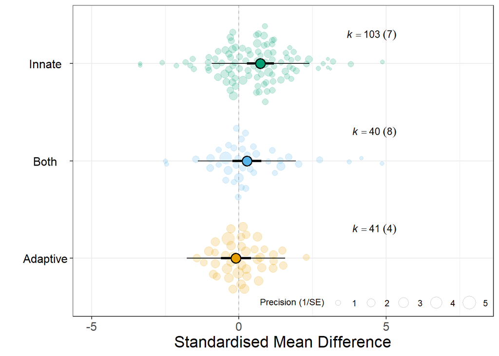

### Meta-model for ectotherms:

- Number of observation with non-missing SMD_arousal: 10
- Number of studies in the dataset for analysis: 1
- Number of species in the dataset for analysis: 1

```
##
## Multivariate Meta-Analysis Model (k = 10; method: REML)
##
##   logLik  Deviance       AIC       BIC      AICc
##  -5.7471   11.4941   17.4941   17.7325   23.4941
##
## Variance Components:
##
##             estim    sqrt  nlvls  fixed  factor
## sigma^2    0.1258  0.3547     10     no   obsID
##
## Test for Residual Heterogeneity:
## QE(df = 8) = 16.2762, p-val = 0.0386
##
## Test of Moderators (coefficients 1:2):
## QM(df = 2) = 3.1010, p-val = 0.2121
##
## Model Results:
##
##                           estimate      se     zval    pval    ci.lb   ci.ub
## Biomarker_categoryBoth      0.5460  0.3531   1.5460  0.1221  -0.1462  1.2381
## Biomarker_categoryInnate   -0.1482  0.1758  -0.8431  0.3992  -0.4928  0.1964
##
## ---
## Signif. codes:  0 '***' 0.001 '**' 0.01 '*' 0.05 '.' 0.1 ' ' 1
```

```
##
## Multivariate Meta-Analysis Model (k = 10; method: REML)
##
##   logLik  Deviance       AIC       BIC      AICc
##  -5.7471   11.4941   17.4941   17.7325   23.4941
##
## Variance Components:
##
##             estim    sqrt  nlvls  fixed  factor
## sigma^2    0.1258  0.3547     10     no   obsID
##
## Test for Residual Heterogeneity:
## QE(df = 8) = 16.2762, p-val = 0.0386
##
## Test of Moderators (coefficients 1:2):
## QM(df = 2) = 3.1010, p-val = 0.2121
##
## Model Results:
##
##                           estimate      se     zval    pval    ci.lb   ci.ub
## Biomarker_categoryBoth      0.5460  0.3531   1.5460  0.1221  -0.1462  1.2381
## Biomarker_categoryInnate   -0.1482  0.1758  -0.8431  0.3992  -0.4928  0.1964
##
## ---
## Signif. codes:  0 '***' 0.001 '**' 0.01 '*' 0.05 '.' 0.1 ' ' 1
```

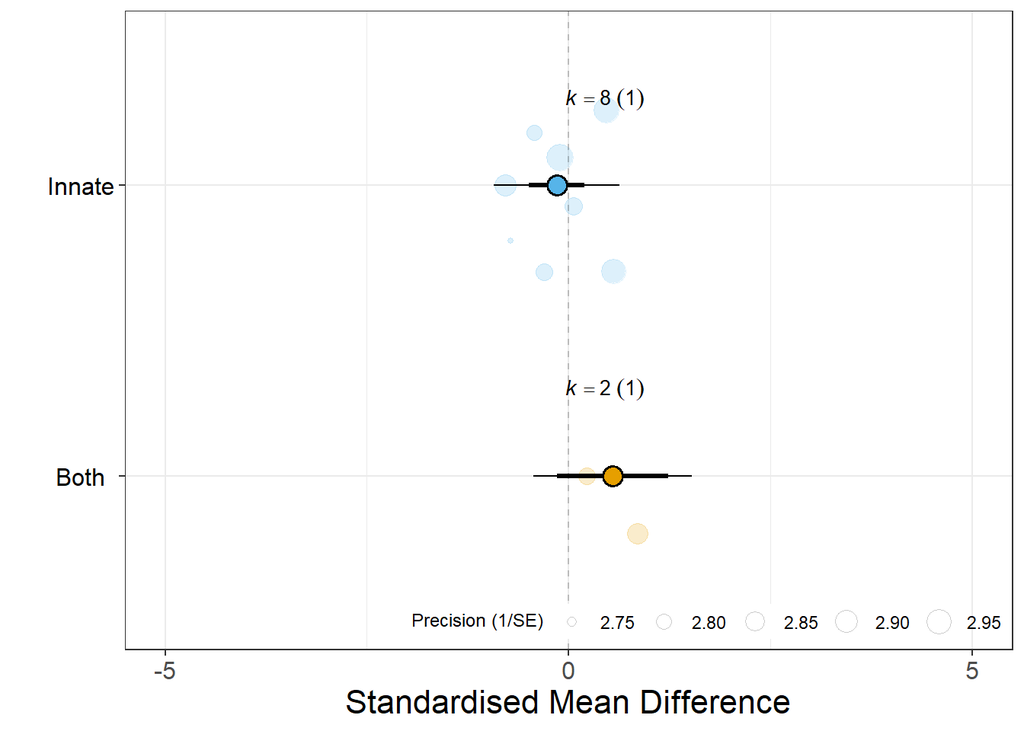